# Foundation lab 3 Explore Code-along

Jeanne McClure

2022-08-23

## 1. Prepare

```r
#load libraries
library(tidyverse)
library(here)
```

## 2. Wrangle

Read in survey data from the previous session

```r
data_to_explore <- read_csv(here("data", "data_to_explore.csv"))
# Choose a way to inspect your datat with what ever function you wish
```

## Explore

#### A. TABLE SUMMARY

```r
#install package if this is first time using skimr


#load library
library(skimr)
```

```r
#skim data
skim(data_to_explore)
```

Data summary

| Name | data_to_explore |
| --- | --- |
| Number of rows | 943 |
| Number of columns | 34 |
| _______________________ |  |
| Column type frequency: |  |
| character | 8 |
| numeric | 23 |
| POSIXct | 3 |
| ________________________ |  |
| Group variables | None |

**Variable type: character**

| skim_variable | n_missing | complete_rate | min | max | empty | n_unique | whitespace |
| --- | --- | --- | --- | --- | --- | --- | --- |
| student_id | 0 | 1.00 | 2 | 6 | 0 | 879 | 0 |
| subject | 0 | 1.00 | 4 | 5 | 0 | 5 | 0 |
| semester | 0 | 1.00 | 4 | 4 | 0 | 4 | 0 |
| section | 0 | 1.00 | 2 | 2 | 0 | 4 | 0 |
| gender | 227 | 0.76 | 1 | 1 | 0 | 2 | 0 |
| enrollment_reason | 227 | 0.76 | 5 | 34 | 0 | 5 | 0 |
| enrollment_status | 227 | 0.76 | 7 | 17 | 0 | 3 | 0 |
| course_id | 281 | 0.70 | 12 | 13 | 0 | 36 | 0 |

**Variable type: numeric**

| skim_variable | n_missing | complete_rate | mean | sd | p0 | p25 | p50 | p75 | p100 | hist |
| --- | --- | --- | --- | --- | --- | --- | --- | --- | --- | --- |
| total_points_possible | 226 | 0.76 | 1619.55 | 387.12 | 1212.00 | 1217.00 | 1676.00 | 1791.00 | 2425.00 | ▇▂▆▁▃ |
| total_points_earned | 226 | 0.76 | 1229.98 | 510.64 | 0.00 | 1002.50 | 1177.13 | 1572.45 | 2413.50 | ▂▂▇▅▂ |
| proportion_earned | 226 | 0.76 | 0.76 | 0.25 | 0.00 | 0.72 | 0.86 | 0.92 | 1.01 | ▁▁▁▃▇ |
| time_spent | 232 | 0.75 | 1828.80 | 1363.13 | 0.45 | 895.57 | 1559.97 | 2423.94 | 8870.88 | ▇▅▁▁▁ |
| time_spent_hours | 232 | 0.75 | 30.48 | 22.72 | 0.01 | 14.93 | 26.00 | 40.40 | 147.85 | ▇▅▁▁▁ |
| int | 293 | 0.69 | 4.30 | 0.60 | 1.80 | 4.00 | 4.40 | 4.80 | 5.00 | ▁▁▂▆▇ |
| val | 287 | 0.70 | 3.75 | 0.75 | 1.00 | 3.33 | 3.67 | 4.33 | 5.00 | ▁▁▆▇▆ |
| percomp | 288 | 0.69 | 3.64 | 0.69 | 1.50 | 3.00 | 3.50 | 4.00 | 5.00 | ▁▁▇▃▃ |
| tv | 292 | 0.69 | 4.07 | 0.59 | 1.00 | 3.71 | 4.12 | 4.46 | 5.00 | ▁▁▂▇▇ |
| q1 | 285 | 0.70 | 4.34 | 0.66 | 1.00 | 4.00 | 4.00 | 5.00 | 5.00 | ▁▁▁▇▇ |
| q2 | 285 | 0.70 | 3.66 | 0.93 | 1.00 | 3.00 | 4.00 | 4.00 | 5.00 | ▁▂▆▇▃ |
| q3 | 286 | 0.70 | 3.31 | 0.85 | 1.00 | 3.00 | 3.00 | 4.00 | 5.00 | ▁▂▇▅▂ |
| q4 | 289 | 0.69 | 4.35 | 0.80 | 1.00 | 4.00 | 5.00 | 5.00 | 5.00 | ▁▁▁▆▇ |
| q5 | 286 | 0.70 | 4.28 | 0.69 | 1.00 | 4.00 | 4.00 | 5.00 | 5.00 | ▁▁▁▇▆ |
| q6 | 285 | 0.70 | 4.05 | 0.80 | 1.00 | 4.00 | 4.00 | 5.00 | 5.00 | ▁▁▃▇▅ |
| q7 | 286 | 0.70 | 3.96 | 0.85 | 1.00 | 3.00 | 4.00 | 5.00 | 5.00 | ▁▁▅▇▆ |
| q8 | 286 | 0.70 | 4.35 | 0.65 | 1.00 | 4.00 | 4.00 | 5.00 | 5.00 | ▁▁▁▇▇ |
| q9 | 286 | 0.70 | 3.55 | 0.92 | 1.00 | 3.00 | 4.00 | 4.00 | 5.00 | ▁▂▇▇▃ |
| q10 | 285 | 0.70 | 4.17 | 0.87 | 1.00 | 4.00 | 4.00 | 5.00 | 5.00 | ▁▁▃▇▇ |
| post_int | 848 | 0.10 | 3.88 | 0.94 | 1.00 | 3.50 | 4.00 | 4.50 | 5.00 | ▁▁▃▇▇ |
| post_uv | 848 | 0.10 | 3.48 | 0.99 | 1.00 | 3.00 | 3.67 | 4.00 | 5.00 | ▂▂▅▇▅ |
| post_tv | 848 | 0.10 | 3.71 | 0.90 | 1.00 | 3.29 | 3.86 | 4.29 | 5.00 | ▁▂▃▇▆ |
| post_percomp | 848 | 0.10 | 3.47 | 0.88 | 1.00 | 3.00 | 3.50 | 4.00 | 5.00 | ▁▂▂▇▂ |

**Variable type: POSIXct**

| skim_variable | n_missing | complete_rate | min | max | median | n_unique |
| --- | --- | --- | --- | --- | --- | --- |
| date_x | 393 | 0.58 | 2015-09-02 15:40:00 | 2016-05-24 15:53:00 | 2015-10-01 15:57:30 | 536 |
| date_y | 848 | 0.10 | 2015-09-02 15:31:00 | 2016-01-22 15:43:00 | 2016-01-04 13:25:00 | 95 |
| date | 834 | 0.12 | 2017-01-23 13:14:00 | 2017-02-13 13:00:00 | 2017-01-25 18:43:00 | 107 |

This output is best for internal use. This is because the output is rich, but not well-suited to exporting to a table that you add, for instance, to a Google Docs or Microsoft Word manuscript. Of course, these values can be entered manually into a table, but we’ll also discuss ways later on to create tables that are ready–or nearly-ready–to be added directly to manuscripts

## B. TIDY to EXPLORE

```r
# using the `select()` and `filter()` functions. In the code chunk below,look at descriptive for just `proportion_earned` , `time_spent` and `gender`, but only for the "OcnA" and "PhysA" subjects.

data_to_explore %>%
  select(c('subject', 'gender', 'proportion_earned', 'time_spent')) %>%
  filter(subject == "OcnA" | subject == "PhysA") %>%
  skim()
```

Data summary

| Name | Piped data |
| --- | --- |
| Number of rows | 249 |
| Number of columns | 4 |
| _______________________ |  |
| Column type frequency: |  |
| character | 2 |
| numeric | 2 |
| ________________________ |  |
| Group variables | None |

**Variable type: character**

| skim_variable | n_missing | complete_rate | min | max | empty | n_unique | whitespace |
| --- | --- | --- | --- | --- | --- | --- | --- |
| subject | 0 | 1.00 | 4 | 5 | 0 | 2 | 0 |
| gender | 48 | 0.81 | 1 | 1 | 0 | 2 | 0 |

**Variable type: numeric**

| skim_variable | n_missing | complete_rate | mean | sd | p0 | p25 | p50 | p75 | p100 | hist |
| --- | --- | --- | --- | --- | --- | --- | --- | --- | --- | --- |
| proportion_earned | 48 | 0.81 | 0.78 | 0.24 | 0.00 | 0.73 | 0.86 | 0.94 | 1.00 | ▁▁▁▃▇ |
| time_spent | 48 | 0.81 | 1828.56 | 1374.13 | 0.58 | 943.07 | 1601.13 | 2356.88 | 8870.88 | ▇▅▁▁▁ |

If you are curious about doing more with {skimr}, check out: [<https://cran.r-project.org/web/packages/skimr/vignettes/skimr.html>](https://cran.r-project.org/web/packages/skimr/vignettes/skimr.html)

#### B. DATA VIZ

ggplot grammar - with layers

##### layers - Scatter Plot

Basic graph 1. data 2. aes 3. geom

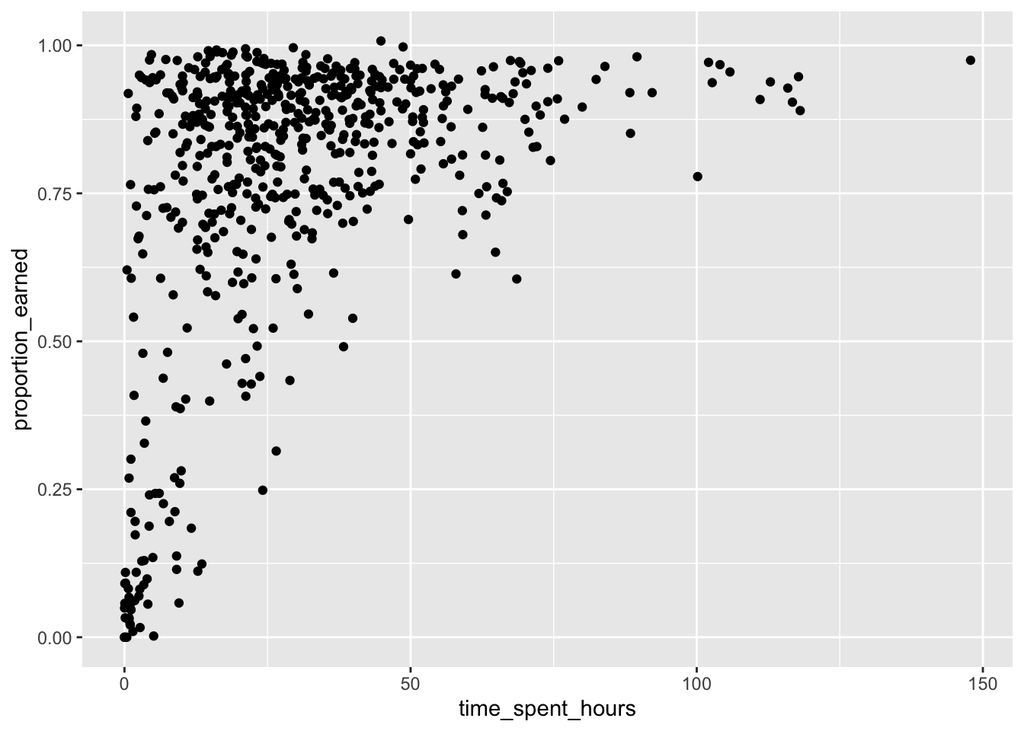

```r
#layer 1: add data and aesthetics mapping
ggplot(data_to_explore, #<<
       aes(x = time_spent_hours,
           y = proportion_earned)) +
#layer 2: +  geom function type
  geom_point() #<<
```

Add **Scale** with different color for enrollment status.

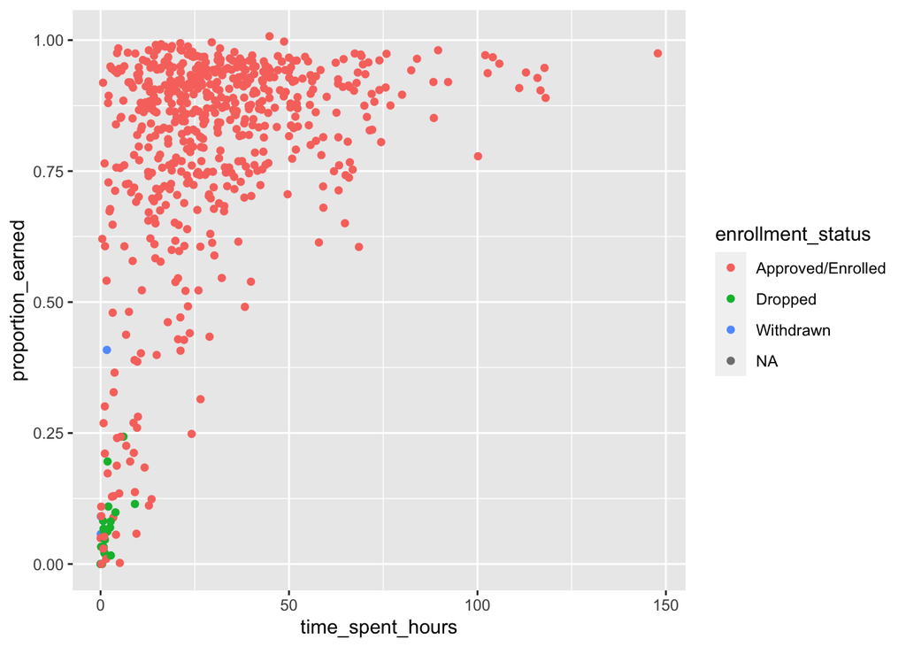

```r
#layer 1: add data and aesthetics mapping
#layer 3: add color scale by type
ggplot(data_to_explore,
       aes(x = time_spent_hours,
           y = proportion_earned,
           color = enrollment_status)) + #<<
#layer 2: +  geom function type
  geom_point()
```

Add another layer with **labs* labeling the title

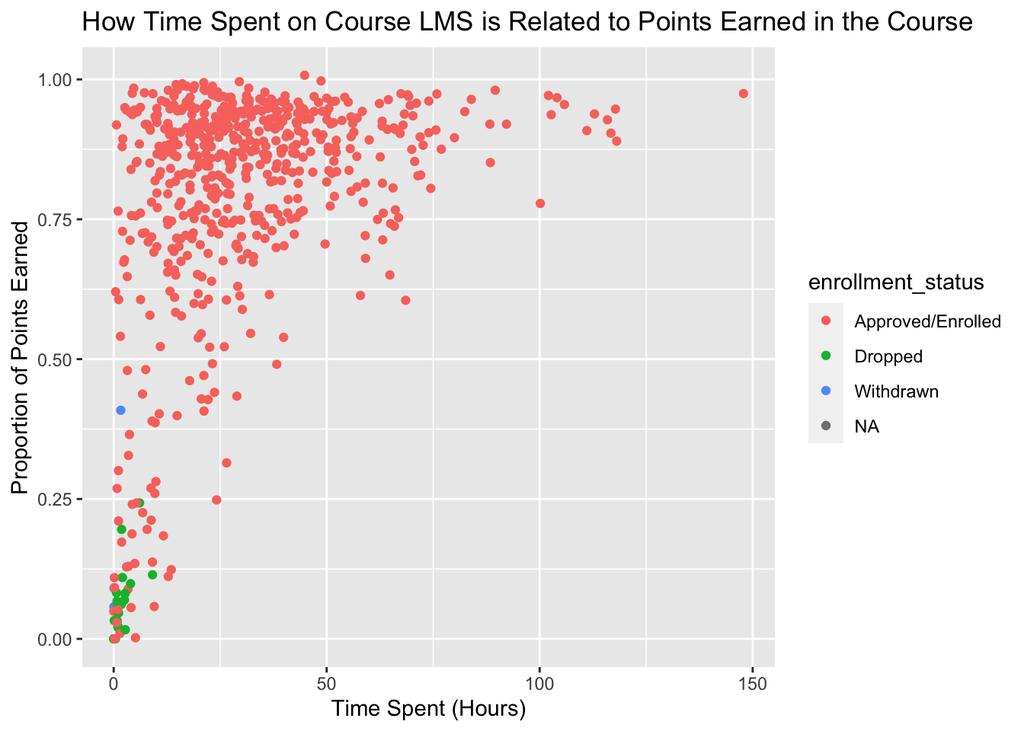

```r
#layer 1: add data and aesthetics mapping
#layer 3: add color scale by type
ggplot(data_to_explore,
       aes(x = time_spent_hours,
           y = proportion_earned,
           color = enrollment_status)) +
#layer 2: +  geom function type
  geom_point() +
#layer 4: add lables
  labs(title="How Time Spent on Course LMS is Related to Points Earned in the Course", x="Time Spent (Hours)", y = "Proportion of Points Earned")
```

Add the **facet** layer

```r
#layer 1: add data and aesthetics mapping
#layer 3: add color scale by type
ggplot(data_to_explore, aes(x = time_spent_hours, y = proportion_earned, color = enrollment_status)) +
#layer 2: +  geom function type
  geom_point() +
#layer 4: add lables
    labs(title="How Time Spent on Course LMS is Related to Points Earned in the Course",
       x="Time Spent (Hours)",
       y = "Proportion of Points Earned")
#layer 5: add facet wrap
  facet_wrap(~ subject)
```

[output not shown]